# OSU Student News Use Survey

# OSU News

Now we turn to news about Ohio State. What do they care about?

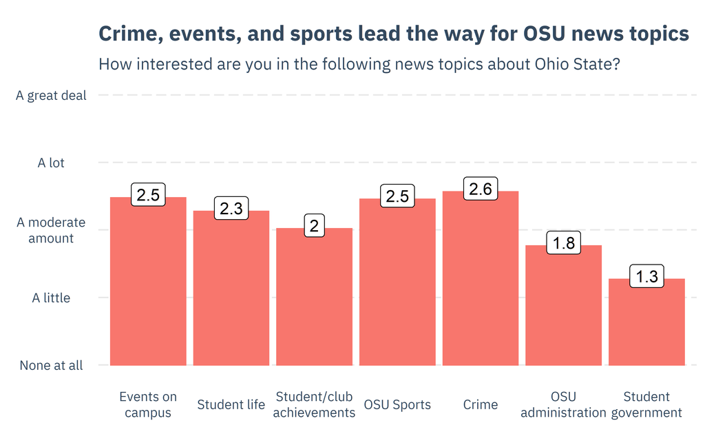

For another way to look at this, we can break it down by each response to get a look at the intensity of opinion. Below we can see there’s a big group of people who really care about sports, despite there being a larger-than-normal group who really don’t care about sports. And not too many are really enthused about campus events, but nobody feels like they don’t care either.

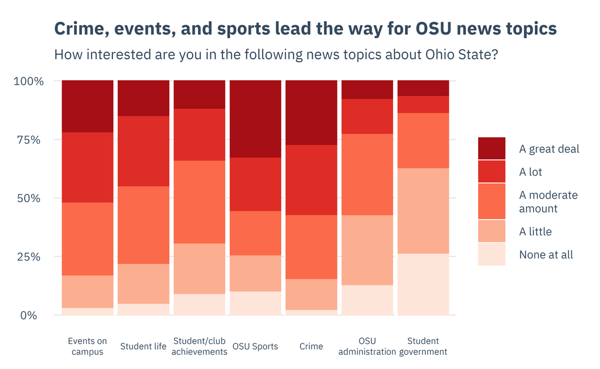

No clear story when it comes to entertainment interests, but there will be an audience for several kinds of local-oriented coverage.

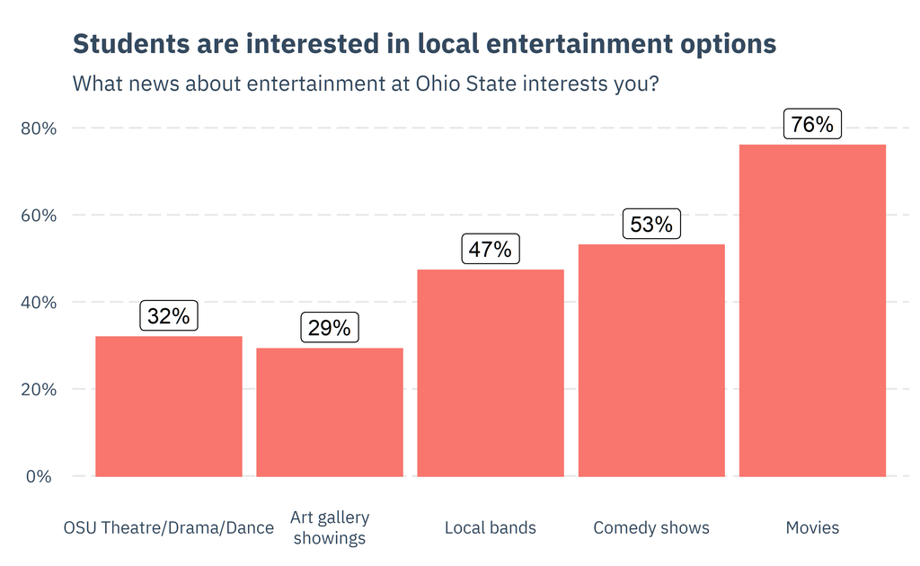

## The Lantern

And finally, let’s look at what students have to say about The Lantern. First, the basics.

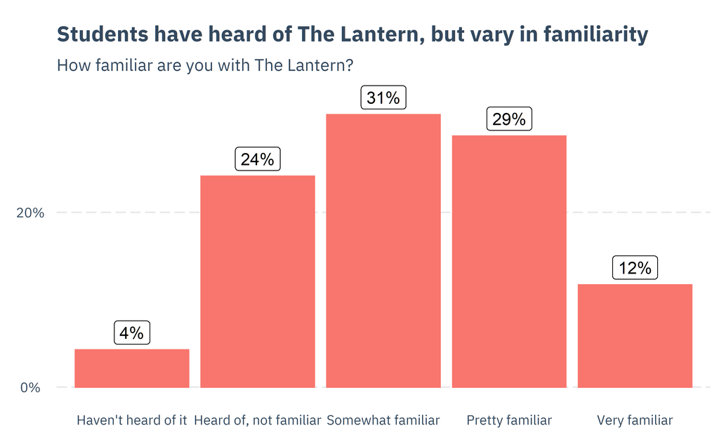

And do they ever use The Lantern to get news?

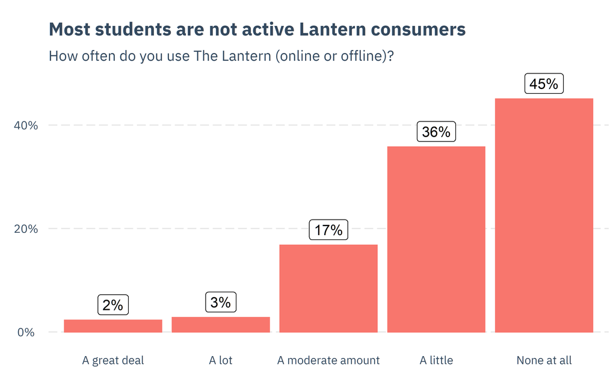

How are they enjoying the new web layout?

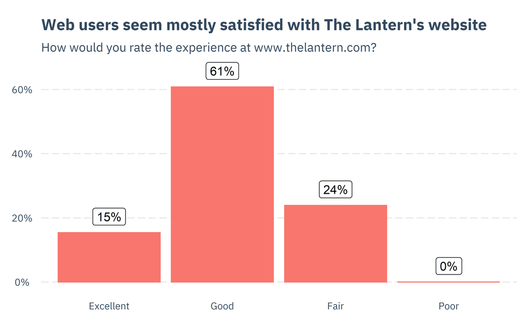

Now let’s try to get answers for why the app isn’t driving a ton of new traffic.

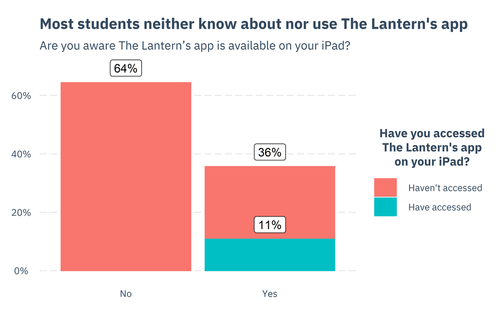

Do students think The Lantern will ask (and answer) the tough questions?

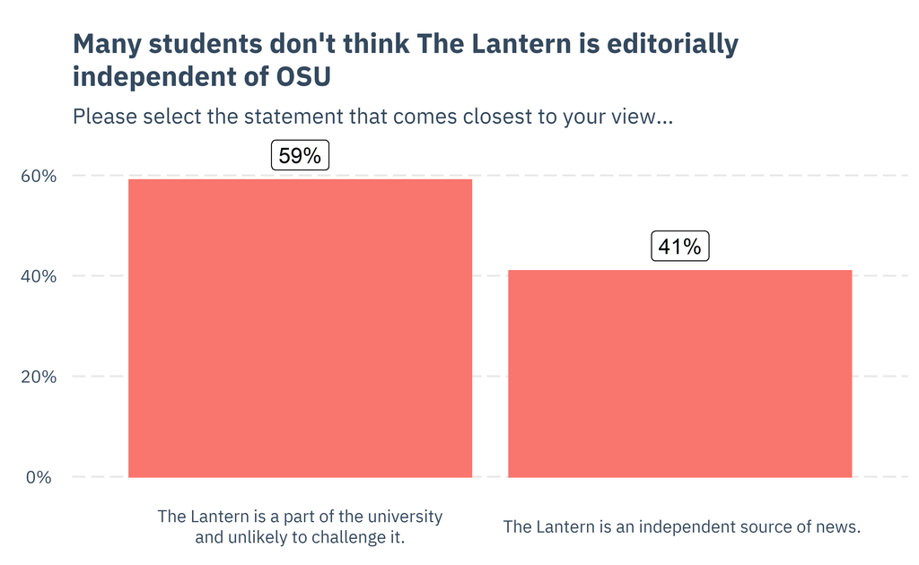

## Other sources of OSU news

Now we check out the competition.

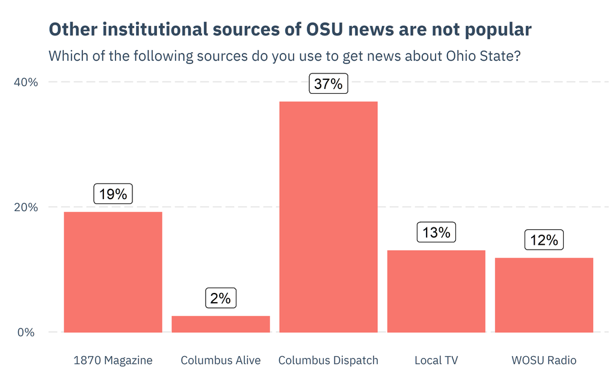

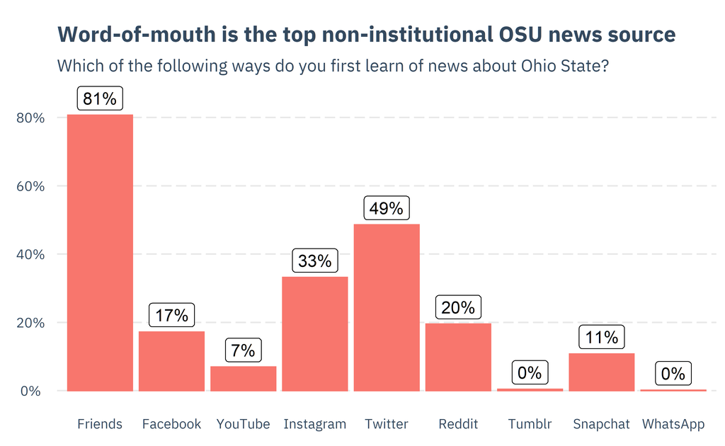

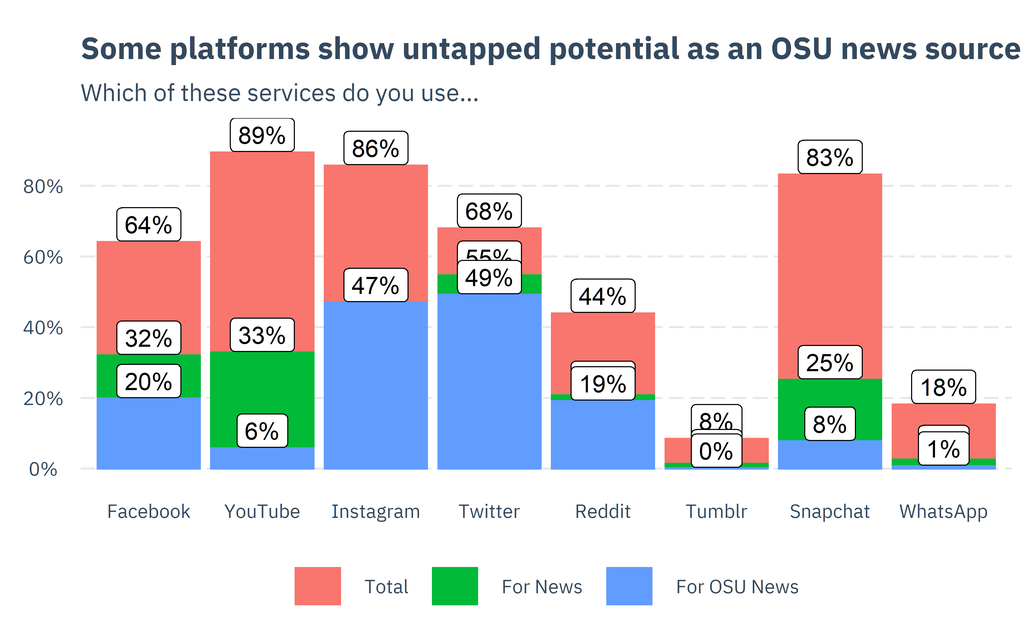

*Note: More respondents said they got “news about Ohio State” from Instagram than said they got “news” from Instagram.*

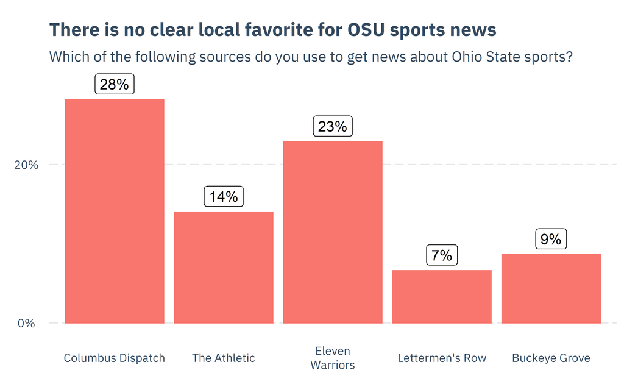